# Classification of Gym exercises using keypoints

The purpose is to develop a model that can analyze the form of people doing different gym exercises. The objective is to implement vision transformers for pose estimation using videos. The focus is to estimate pose using vision transformers, and then apply a classifier to determine the exercise they are doing based on the keypoints and their temporal evolution.

The vision transformer model being used is an adaptation of [VitPose](https://github.com/ViTAE-Transformer/ViTPose) (Xu et al., 2022).

We used a Temporal Convolution Network to classify the keypoints that were generated from the Pose estimator.

Section A of the report below describes this work, and has the following parts:

1. Data pre-processing
2. Pose Estimation
3. Classification

Section B describes a holistic discussion of the overall results.

Shown below is the Model architecture we used

[figure not shown]

## Links

```python
# Colab Link
https://colab.research.google.com/drive/1rudcGUj16VXiqVZGi0Lpn1IeXBfuXeR9?usp=sharing
```

```python
# Dataset Link
https://utoronto-my.sharepoint.com/:f:/g/personal/timoteo_frelau_mail_utoronto_ca/EhZ0vtU69VZIis0kp9hFRgQBegF_YGBKzzmJ0-KbyQQAOg?e=NqswQU
```

## **SECTION A**##

### **Part A: Data Collection and Preprocessing**

Our Dataset comprises of videos that were gathared from popular social media platforms such as YouTube and Instagram. Additionally, we recorded our own videos (as test data). Our focus was on three key exercises: Snatch, Deadlift and Squat resulting in a balanced dataset comprising of 183 videos.

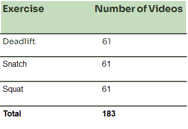

While choosing the videos various aspects have been considered based on our learnings in applying the models on videos. Videos with multiple people, objects have not been chosen. Videos with similar angle of recording were chosen. The start and end pose of the each exercises were determined and the videos are cropped to start and end at those poses.

After downloading the videos, we cropped them around the person so that only the human was left on the frames. We also cropped the video length to one repetition.  
Sample of pre-processed data:

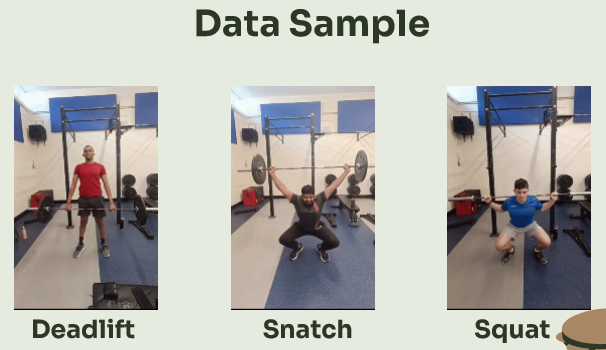

### **Part B: Pose Estimation**###

This model was pre-existing.  
The video in mp4 format is loaded into a pre-trained ViTPose Transformer model that was implemented by us using pytorch. The processed frames from Pose estimator are then used to visualize the poses of the humans in the data. This is how we knew if a video was good to fit for the classifier, or if we had to reject it because of poor keypoints estimation of the model.  
We also collect the keypoints from the estimator as a numpy array and these are saved as a .npz file for each video.

### Cloning our Pose Estimation repo

The pose estimation is achieved by running the preprocesssed dataset into a custom pretrained ViTPose model to extract the keypoints. The output is also visualized for evaluation. The work done to implement our Pose estimation can be found at the [link](https://github.com/AkshithRajkumar/ViTPose_gym_classification) here.

```python
# Clone the GitHub repository into Google Colab
!git clone https://github.com/AkshithRajkumar/ViTPose_gym_classification.git
```

```
Cloning into 'ViTPose_gym_classification'...
remote: Enumerating objects: 1199, done.
remote: Counting objects: 100% (258/258), done.
remote: Compressing objects: 100% (241/241), done.
remote: Total 1199 (delta 13), reused 256 (delta 12), pack-reused 941
Receiving objects: 100% (1199/1199), 166.52 MiB | 28.41 MiB/s, done.
Resolving deltas: 100% (16/16), done.
```

```python
from google.colab import drive

# Mount Google Drive
drive.mount('/content/drive')
```

```python
#load vitpose-b-multi-coco.pth model from drive

#Alternatively you can download the model and load into the colab as well

model_path = '/content/drive/MyDrive/Colab Notebooks/MIE1517 Project/vitpose-b-multi-coco.pth'
```

```python
!pip install ffmpeg
```

```
  Preparing metadata (setup.py) ... done
```

```python
%cd /content/ViTPose_gym_classification
!python inference1.py
```

```
/content/ViTPose_gym_classification
!!!!
363it [14:36,  2.42s/it]
```

This shows the way to run it for one video. After cloning the repo, we have multiple inference codes that inplements ViTPose on different structured data such as folders, singular files, either by passing the folder location, or just the video location, or by updating the code to the location prior to running.

### **Part C: Classifier**###

The classifier is a temporal convolutional network that takes as input the keypoints, and classify the video as one of the three exercises.

First, we import the necessary libraries.

```python
import torch
import torch.nn as nn
import torch.nn.functional as F
import torch.optim as optim
import torchvision.models as models
import torchvision.transforms as transforms
import os
import numpy as np
from sklearn.model_selection import train_test_split
import torch.optim.lr_scheduler as lr_scheduler
import pandas as pd
```

We had to create a custom implementation of the PyTorch Dataset class to load the keypoints that were saved as a numpy .npz file by VitPose.

```python
from torch.utils.data import Dataset

class CustomDataset(Dataset):
    def __init__(self, root_dir):
        self.root_dir = root_dir
        self.classes = sorted(os.listdir(root_dir))
        self.file_paths = self._get_file_paths()

    def _get_file_paths(self):
        file_paths = []
        for label, class_name in enumerate(self.classes):
            class_dir = os.path.join(self.root_dir, class_name)
            files = os.listdir(class_dir)
            for file in files:
                file_paths.append((os.path.join(class_dir, file), label))
        return file_paths

    def __len__(self):
        return len(self.file_paths)

    def __getitem__(self, idx):
        file_path, label = self.file_paths[idx]
        data = np.load(file_path)
        data = data['reconstruction'][:, :, :2]
        # Pad the data to a fixed length
        last_row = np.expand_dims(data[-1], 0)
        fixed_length = 150
        if len(data) < fixed_length:
            data = np.concatenate([data, np.tile(last_row, (fixed_length - len(data), 1, 1))])
        else:
            data = data[:fixed_length]
        features = torch.from_numpy(data).float()  # Assuming features are stored under the key 'features'
        return features, label
```

We then carry out some sanity checks, to confirm first whether all the .npz files have been included in CustomDataset, and then to check the dimensions of the resulting tensors.

```python
data = CustomDataset(r"new_keypoints_30_03")
print(len(data))
```

```
182
```

```python
tmp = next(iter(data))
print(tmp[0].shape, tmp[1])
```

```
torch.Size([150, 17, 2]) 0
```

```python
next(iter(data))[0].shape, next(iter(data))[1]
```

```
(torch.Size([150, 17, 2]), 0)
```

```python
# use the DataLoader class to load the data
from torch.utils.data import DataLoader

batch_size = 16
shuffle = True

squats_loader = DataLoader(data, batch_size=batch_size, shuffle=shuffle)

# Example usage
for batch in squats_loader:
    features, labels = batch
    print(features.shape, labels.shape)
    break

print(labels)
```

```
torch.Size([16, 150, 17, 2]) torch.Size([16])
tensor([1, 1, 0, 1, 0, 1, 1, 1, 2, 2, 0, 1, 0, 0, 1, 0])
```

Then we build our temporal convolutional network.

```python
class TCN(nn.Module):
    def __init__(self, input_size, num_channels, kernel_size, dropout):
        super(TCN, self).__init__()
        self.input_size = input_size
        self.num_channels = num_channels
        self.kernel_size = kernel_size
        self.dropout = dropout
        self.conv_layers = nn.ModuleList()
        self.batch_norm_layers = nn.ModuleList()
        self.num_layers = len(num_channels)

        # Modified here
        in_channels = input_size[-1]

        for i in range(self.num_layers):
            dilation = 2 ** i
            padding = (kernel_size - 1) * dilation // 2

            out_channels = num_channels[i]
            conv_layer = nn.Conv1d(in_channels, out_channels, kernel_size, padding=padding, dilation=dilation)
            self.conv_layers.append(conv_layer)
            batch_norm_layer = nn.BatchNorm1d(out_channels)
            self.batch_norm_layers.append(batch_norm_layer)

            in_channels = out_channels

        self.linear = nn.Linear(num_channels[-1], 3)
        self.dropout_layer = nn.Dropout(dropout)
        self.sigmoid = nn.Sigmoid()

    def forward(self, x):
        batch_size, num_poses, num_joints, num_coords = x.size()
        x = x.reshape(batch_size, num_poses * num_joints, num_coords).transpose(1, 2)
        for i in range(self.num_layers):
            conv_layer = self.conv_layers[i]
            batch_norm_layer = self.batch_norm_layers[i]
            x = conv_layer(x)
            x = batch_norm_layer(x)
            x = nn.functional.relu(x)
            x = self.dropout_layer(x)
        x = x.mean(dim=2)
        x = self.linear(x)
        x = self.sigmoid(x)
        return x
```

```python
use_cuda = True
```

```python
torch.manual_seed(1)
if torch.cuda.is_available() and use_cuda:
    device = torch.device('cuda')
else:
    device = torch.device('cpu')

print(device)
```

```
cpu
```

```python
# Train, validation, and test splits
train_size = 100
val_size = 50
test_size = 32

seed = 20

train_data, test_data = train_test_split(data, test_size=test_size, train_size=150, shuffle=True, random_state=seed)
train_data, val_data = train_test_split(train_data, test_size=val_size, train_size=train_size, shuffle=True, random_state=seed)
```

```python
print(len(train_data), len(val_data))
print(len(test_data))
```

```
100 50
32
```

Some more sanity checks, this time to see if the train test split has introduced significant imbalances into our data. It has introduced some imbalance, but it's minor.

```python
# write a code to print the number of data in each label of 1 and 0
for i in range(3):
    print(f"Number of data in label {i}: {len([label for _, label in train_data if label == i])}")
```

```
Number of data in label 0: 35
Number of data in label 1: 31
Number of data in label 2: 34
```

```python
for i in range(3):
    print(f"Number of data in label {i}: {len([label for _, label in val_data if label == i])}")
```

[output not shown]

```python
train_dl = DataLoader(train_data, batch_size=batch_size, shuffle=True)
val_dl = DataLoader(val_data, batch_size=4, shuffle=True)
```

```python
def get_accuracy(model, data_loader, device):
    model.eval()
    correct = 0
    total = 0
    with torch.no_grad():
        for inputs, labels in data_loader:
            inputs, labels = inputs.to(device), labels.to(device)
            outputs = model(inputs)
            _, predicted = torch.max(outputs, 1)
            total += labels.size(0)
            correct += (predicted.squeeze() == labels).sum().item()
    return correct / total
```

Here is our train function.

```python
import os
import torch.nn.utils as utils

def train(model, train_loader, val_loader, optimizer, scheduler, criterion, device, n_epochs=30):
    train_loss_history = []
    val_loss_history = []
    train_acc_history = []
    val_acc_history = []

    model.to(device)

    prev_loss = 10000
    save_models = './saved_models_150'  # Define the path to save models
    os.makedirs(save_models, exist_ok=True)  # Create the directory if it doesn't exist

    for epoch in range(n_epochs):
        model.train()

        train_loss = 0.0
        for inputs, labels in train_loader:
            optimizer.zero_grad()
            inputs = inputs.to(device)
            labels = labels.to(device)

            outputs = model(inputs)
            loss = criterion(outputs.squeeze(), labels)

            loss.backward()
            utils.clip_grad_norm_(model.parameters(), 1.0)
            optimizer.step()
            train_loss += loss.item() * inputs.size(0)

        train_loss /= len(train_loader.dataset)
        train_loss_history.append(train_loss)
        train_acc = get_accuracy(model, train_loader, device)
        train_acc_history.append(train_acc)


        val_loss = 0.0

        model.eval()
        with torch.no_grad():
            for inputs, labels in val_loader:
                inputs = inputs.to(device)
                labels = labels.to(device)

                outputs = model(inputs)
                loss = criterion(outputs.squeeze(), labels)

                val_loss += loss.item() * inputs.size(0)

        val_loss /= len(val_loader.dataset)
        val_loss_history.append(val_loss)
        val_acc = get_accuracy(model, val_loader, device)
        val_acc_history.append(val_acc)

        scheduler.step(val_loss)

        if val_loss < prev_loss:
            prev_loss = val_loss
            path2save = os.path.join(save_models, f"model_e{epoch+1}_l{val_loss:.4f}.pth")
            torch.save(model.state_dict(), path2save)
            print(f"Model saved in {path2save}")

        print(f'Epoch {epoch+1}/{n_epochs}: Train Loss = {train_loss:.4f}, Val Loss = {val_loss:.4f}')
        print(f'Train Accuracy = {train_acc:.4f}, Val Accuracy = {val_acc:.4f}')
    return train_loss_history, val_loss_history, train_acc_history, val_acc_history
```

```python
from torch.optim.lr_scheduler import ReduceLROnPlateau
model = TCN(input_size=(150, 17 ,2), num_channels=[8, 8, 8, 8], kernel_size=3, dropout=0.2).to(device)

optimizer = torch.optim.Adam(model.parameters(), lr=0.005, amsgrad=True)
# scheduler = lr_scheduler.StepLR(optimizer, step_size=10, gamma=0.90)
scheduler = ReduceLROnPlateau(optimizer, mode='min', factor=0.2, patience=3, verbose=True)
criterion = nn.CrossEntropyLoss()
```

### **Part D: Quantitative analysis**

#### **Part(i): Training and validation accuracy**

```python
train_loss_history, val_loss_history, train_acc_history, val_acc_history = train(model, train_dl, val_dl, optimizer, scheduler, criterion, device, 100)
```

```
Model saved in ./saved_models_150\model_e1_l1.1001.pth
Train Accuracy = 0.3100, Val Accuracy = 0.3200
Model saved in ./saved_models_150\model_e2_l1.0972.pth
Train Accuracy = 0.4100, Val Accuracy = 0.4000
Train Accuracy = 0.4300, Val Accuracy = 0.3400
Model saved in ./saved_models_150\model_e4_l1.0933.pth
Train Accuracy = 0.5200, Val Accuracy = 0.3600
Model saved in ./saved_models_150\model_e5_l1.0847.pth
Train Accuracy = 0.5500, Val Accuracy = 0.4200
Model saved in ./saved_models_150\model_e6_l1.0740.pth
Train Accuracy = 0.5700, Val Accuracy = 0.4800
Model saved in ./saved_models_150\model_e7_l1.0662.pth
Train Accuracy = 0.6000, Val Accuracy = 0.4200
Model saved in ./saved_models_150\model_e8_l1.0421.pth
Train Accuracy = 0.5900, Val Accuracy = 0.4400
Model saved in ./saved_models_150\model_e9_l1.0263.pth
Train Accuracy = 0.7100, Val Accuracy = 0.6200
Model saved in ./saved_models_150\model_e10_l1.0138.pth
Train Accuracy = 0.6600, Val Accuracy = 0.5000
Model saved in ./saved_models_150\model_e11_l0.9996.pth
Train Accuracy = 0.7100, Val Accuracy = 0.5800
Train Accuracy = 0.6500, Val Accuracy = 0.6000
Model saved in ./saved_models_150\model_e13_l0.9898.pth
Train Accuracy = 0.6700, Val Accuracy = 0.6000
Model saved in ./saved_models_150\model_e14_l0.9796.pth
Train Accuracy = 0.7600, Val Accuracy = 0.5200
Model saved in ./saved_models_150\model_e15_l0.9630.pth
Train Accuracy = 0.7300, Val Accuracy = 0.6800
Model saved in ./saved_models_150\model_e16_l0.9351.pth
Train Accuracy = 0.7900, Val Accuracy = 0.6400
Model saved in ./saved_models_150\model_e17_l0.9205.pth
Train Accuracy = 0.7600, Val Accuracy = 0.6200
Model saved in ./saved_models_150\model_e18_l0.8908.pth
Train Accuracy = 0.8500, Val Accuracy = 0.7000
Train Accuracy = 0.7900, Val Accuracy = 0.6400
Model saved in ./saved_models_150\model_e20_l0.8705.pth
Train Accuracy = 0.8200, Val Accuracy = 0.6800
Model saved in ./saved_models_150\model_e21_l0.8519.pth
Train Accuracy = 0.8600, Val Accuracy = 0.7200
Model saved in ./saved_models_150\model_e22_l0.8381.pth
```

[output cut: 73 more lines]

```
Train Accuracy = 0.9500, Val Accuracy = 0.8600
Train Accuracy = 0.9500, Val Accuracy = 0.8600
Train Accuracy = 0.9400, Val Accuracy = 0.8600
Train Accuracy = 0.9500, Val Accuracy = 0.8400
Train Accuracy = 0.9400, Val Accuracy = 0.8600
Train Accuracy = 0.9500, Val Accuracy = 0.8400
Train Accuracy = 0.9500, Val Accuracy = 0.8600
Train Accuracy = 0.9500, Val Accuracy = 0.8400
Train Accuracy = 0.9300, Val Accuracy = 0.8600
Train Accuracy = 0.9300, Val Accuracy = 0.8600
Train Accuracy = 0.9400, Val Accuracy = 0.8400
Train Accuracy = 0.9500, Val Accuracy = 0.8400
Train Accuracy = 0.9500, Val Accuracy = 0.8400
Train Accuracy = 0.9400, Val Accuracy = 0.8600
Train Accuracy = 0.9500, Val Accuracy = 0.8600
```

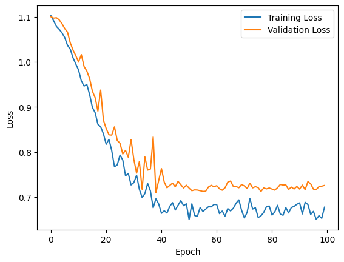

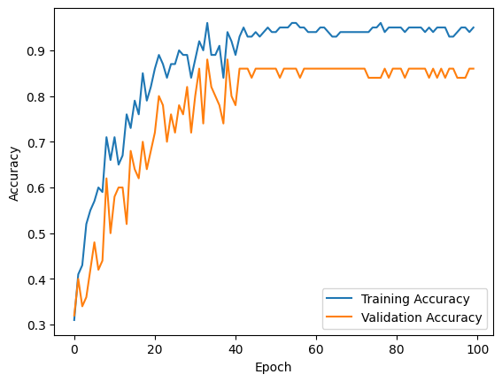

```python
# Plot the training and validation loss
import matplotlib.pyplot as plt

plt.plot(train_loss_history, label='Training Loss')
plt.plot(val_loss_history, label='Validation Loss')
plt.xlabel('Epoch')
plt.ylabel('Loss')
plt.legend()
plt.show()

# Plot the training and validation accuracy
plt.plot(train_acc_history, label='Training Accuracy')
plt.plot(val_acc_history, label='Validation Accuracy')
plt.xlabel('Epoch')
plt.ylabel('Accuracy')
plt.legend()
plt.show()
```

Both training and validation loss and accuracy show improvement, indicating effective learning. However, around the 40th epoch, we observe a stabilization in performance, where further training does not significantly improve the model's accuracy.

#### **Part (ii): Inference**

```python
def inference(model, data_loader, device):
    predictions = []
    labels = []
    model.eval()
    with torch.no_grad():
        for inputs, labels_batch in data_loader:
            inputs = inputs.to(device)
            labels_batch = labels_batch.to(device)
            outputs = model(inputs)
            _, predicted = torch.max(outputs, 1)
            predictions.extend(predicted.cpu().numpy())
            labels.extend(labels_batch.cpu().numpy())
    return predictions, labels
```

```python
from sklearn.metrics import classification_report
train_predictions, train_labels = inference(model, train_dl, device)
val_predictions, val_labels = inference(model, val_dl, device)

# Compute classification report for train and val datasets
train_report = classification_report(train_labels, train_predictions)
val_report = classification_report(val_labels, val_predictions)

print("Classification Report for Train Data:")
print(train_report)
print("Classification Report for Validation Data:")
print(val_report)
```

```
Classification Report for Train Data:
              precision    recall  f1-score   support

           0       0.92      1.00      0.96        35
           1       1.00      0.94      0.97        31
           2       0.94      0.91      0.93        34

    accuracy                           0.95       100
   macro avg       0.95      0.95      0.95       100
weighted avg       0.95      0.95      0.95       100

Classification Report for Validation Data:
              precision    recall  f1-score   support

           0       0.74      1.00      0.85        17
           1       0.94      1.00      0.97        16
           2       1.00      0.59      0.74        17

    accuracy                           0.86        50
   macro avg       0.89      0.86      0.85        50
weighted avg       0.89      0.86      0.85        50
```

```python
# Save the model checkpoint
torch.save(model.state_dict(), 'tcn_model_ex3_150.pth')
```

```python
# testdata = CustomDataset(r"test_npz_files")

# # Create DataLoader for test data
# test_dl = DataLoader(testdata, batch_size=4, shuffle=True)
```

```python
for i in range(3):
    print(f"Number of data in label {i}: {len([label for _, label in test_data if label == i])}")
```

```
Number of data in label 0: 8
Number of data in label 1: 11
Number of data in label 2: 13
```

```python
test_dl = DataLoader(test_data, batch_size=4, shuffle=True)
```

```python
# test accuracy
model.load_state_dict(torch.load('saved_models_150\model_e39_l0.7096.pth'))

test_acc = get_accuracy(model, test_dl, device)
print(f'Test Accuracy = {test_acc:.4f}')
```

```
Test Accuracy = 0.9375
```

```python
from sklearn.metrics import classification_report

# Assuming your model is named 'model' and you have a test DataLoader named 'test_dl'
# Iterate over test DataLoader to make predictions
model.eval()
all_predictions = []
all_labels = []
misclassified_samples = []  # Initialize list to store misclassified samples
misclassified_labels = []
misclassified_predictions = []

with torch.no_grad():
    for inputs, labels in test_dl:
        inputs = inputs.to(device)
        labels = labels.to(device)
        print(inputs.shape)
        # Forward pass
        outputs = model(inputs)

        # Convert outputs to predicted labels (e.g., using argmax)
        _, predicted = torch.max(outputs, 1)


        # Append predicted labels and ground truth labels to lists
        all_predictions.extend(predicted.cpu().numpy())
        all_labels.extend(labels.cpu().numpy())

        for i in range(len(labels)):
            if predicted[i] != labels[i]:
                misclassified_samples.append(inputs[i].cpu().numpy())
                misclassified_labels.append(labels[i].cpu().item())
                misclassified_predictions.append(predicted[i].cpu().item())

# Compute classification report
report = classification_report(all_labels, all_predictions)
print(report)
```

```
torch.Size([4, 150, 17, 2])
torch.Size([4, 150, 17, 2])
torch.Size([4, 150, 17, 2])
torch.Size([4, 150, 17, 2])
torch.Size([4, 150, 17, 2])
torch.Size([4, 150, 17, 2])
torch.Size([4, 150, 17, 2])
torch.Size([4, 150, 17, 2])
              precision    recall  f1-score   support

           0       0.89      1.00      0.94         8
           1       0.92      1.00      0.96        11
           2       1.00      0.85      0.92        13

    accuracy                           0.94        32
   macro avg       0.94      0.95      0.94        32
weighted avg       0.94      0.94      0.94        32
```

Looking at the classification report: The averages metrics for the training data are all around 95%, indicating balanced performance across classes. While precision and recall for Deadlift and Snatch classes are relatively high in the validation data, there is a notable drop in recall for the Squat class, which is reflected in the lower overall accuracy. The overall accuracy of test data is 94%, indicating that the model performs well on unseen data.

#### **Part(iii): Confusion matrix**

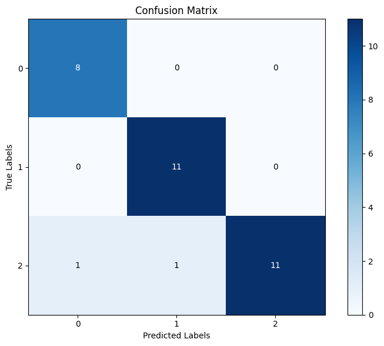

```
[[ 8  0  0]
 [ 0 11  0]
 [ 1  1 11]]
```

```python
import numpy as np
import matplotlib.pyplot as plt
from sklearn.metrics import confusion_matrix

# Compute confusion matrix
conf_matrix = confusion_matrix(all_labels, all_predictions)

# Plot confusion matrix
plt.figure(figsize=(8, 6))
plt.imshow(conf_matrix, interpolation='nearest', cmap=plt.cm.Blues)
plt.title('Confusion Matrix')
plt.colorbar()
classes = np.unique(all_labels)
tick_marks = np.arange(len(classes))
plt.xticks(tick_marks, classes)
plt.yticks(tick_marks, classes)

fmt = 'd'
thresh = conf_matrix.max() / 2.
for i in range(conf_matrix.shape[0]):
    for j in range(conf_matrix.shape[1]):
        plt.text(j, i, format(conf_matrix[i, j], fmt),
                 ha="center", va="center",
                 color="white" if conf_matrix[i, j] > thresh else "black")

plt.xlabel('Predicted Labels')
plt.ylabel('True Labels')
plt.tight_layout()
plt.show()
print(conf_matrix)
```

The confusion matrix shows that the model made very few misclassifications, with only one misclassification each between Deadlift and Squat, and between Snatch and Squat.

### **Part E: Qualitative analysis**

The following code identifies missclassified examples.

```python
for sample, true_label, pred in zip(misclassified_samples, misclassified_labels, misclassified_predictions):
    print("True Label:", true_label)
    print("Predicted Label:", pred)
    print("Misclassified Sample Data:", sample)
    print("-" * 50)  # Separator for clarity
```

[output not shown]

[output cut: 49 more lines]

[output not shown]

```python
import os

# Directory containing .npz files
npz_dir = 'new_keypoints_30_03'

# List to store the paths of matched .npz files
matched_files = []

# Iterate over directories containing .npz files
for root, dirs, files in os.walk(npz_dir):
    for file in files:
        if file.endswith('.npz'):
            npz_path = os.path.join(root, file)

            # Load .npz file
            npz_data = np.load(npz_path)
            npz_data = npz_data['reconstruction'][:, :, :2]
            # Pad the data to a fixed length
            last_row = np.expand_dims(npz_data[-1], 0)
            fixed_length = 150
            if len(npz_data) < fixed_length:
                npz_data = np.concatenate([npz_data, np.tile(last_row, (fixed_length - len(npz_data), 1, 1))])
            else:
                npz_data = npz_data[:fixed_length]

            # Compare npz_data with misclassified data
            # Assuming misclassified_data is a list of misclassified data
            for data, lab, pre in zip(misclassified_samples, misclassified_labels, misclassified_predictions):
                # Check if data matches with npz_data
                if np.all(npz_data == data):
                    matched_files.append(npz_path)
                    print("True Label:", lab, "Predicted Label:", pre)
                    break  # Exit loop if match is found

# Print paths of matched .npz files
for file in matched_files:
    print("Matched .npz file:", file)
```

```
True Label: 2 Predicted Label: 1
True Label: 2 Predicted Label: 0
Matched .npz file: new_keypoints_30_03\squats\s_12.npz
Matched .npz file: new_keypoints_30_03\squats\s_42.npz
```

The two following squat videos are missclassified:

[figure not shown]

[figure not shown]

1. The first video has an actual Label of Squat and a predicted Label of Snatch. This could be because the observed temporal dynamics closely resemble the characteristic motion pattern of a snatch exercise, wherein the arms move from a lower to an upper position in a similar manner. This similarity in movement trajectory likely led to the misclassification.

2. The second video has an actual Label of Squat as well but a predicted Label of Deadlift. A possible explanation of missclassification is the movement captured in this data closely resembles the mechanics of a deadlift, characterized by a consistent downward arm position throughout the action. This similarity in motion likely led to the misclassification.

### **Part F: Performance on New Data**##

The model interface follows the same flow as the pipeline. Initially, a video is chosen via file browsing.

The video is processed through VitPose to generate keypoints, which can be overlaid on the original video.  
This video is correctly classified as a deadlift and all keypoints are accurately inferred by VitPose, shot from the front with a steady camera at nearly eye level.

[figure not shown]

Now let’s look at another video taken from online.  
As we can see, this is a video of a squat exercise.

We notice that this video has several obscured keypoints and a few seem to frequently switch.  
We see that the video is misclassified as a result of this. This could be due to lack of such angled data in training set.

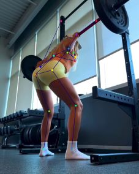

# **Section B**

## **Discussion of the overall results:**

**Performance of the model and learnings from the project**

Overall our model is working very well.

1. The general trend seen with each class in terms of number of frames to cover a single repetition of the exercise varies. The squat has the least number(80), while deadlift and snatch are close to 150).  
   We ended up padding the squat videos with last frame to match the length of deadlifts and snatches effectively extended the length of the squat videos without necessarily adding meaningful temporal information.  
   The addition of padded frames to the squat videos may increase the risk of overfitting, especially if the model learns to exploit patterns specific to the padding rather thanexercise movements. This might be a reason why the model is performing relatively bad with unseen squat data.
2. The model seems to focus on Distinct Hand Movements. Deadlifts, squats, and snatches are distinct exercises that often involve different hand movements or positions. For example, during a deadlift, the hands typically grip a weights, whereas during a squat, the hands may be free or holding onto a support. while, snatches involve rapid hand movements to lift a weight overhead. Hand movements could be key discriminative features for the model to differentiate between the different exercises .The model might be leveraging these temporal patterns to make accurate predictions.
3. And finally, we see that data with moving camera seemed to drastically affect model performance.  
   In videos with a fixed camera, consecutive frames often exhibit high temporal consistency, making it easier for the model to track the subject's pose over time. However, in videos with a moving camera, the subject's appearance may change from one frame to the next due to camera motion, making it more challenging for the model to maintain temporal consistency. This variability can make it harder for the pose estimator to accurately detect key points.

## **Summary of related work**

There are many different methods that can be used for action classification. These include using applying CNNs on the individual images [(Karpathy et al., 2014)](https://static.googleusercontent.com/media/research.google.com/fr//pubs/archive/42455.pdf), and recurrent neural networks [(Ng et al., 2015)](https://arxiv.org/pdf/1503.08909.pdf). The recurrent approaches are however more difficult to train, while the approach applying CNNs to individual frames doesn't make use of the full available spatiotemporal information.

One approach that we applied to our data to provide us with a baseline model was the use of (2+1)D CNNs, similar to the work of [Tran et al. (2018)](https://arxiv.org/pdf/1711.11248v3). This ResNet is inspired by 3D convolutional neural networks, which have a single kernel that traverses the spatial and temporal dimensions.

The study that most closely ressembles the work that we are doing here is that by [Singh et al. (2022)](https://arxiv.org/pdf/2209.03561.pdf), who applied vision transformers to violence detection, in the process developing the Video Vision Transformers (ViViT) model. This model however adapts the vision transformers directly to do the classification task, whereas we use them merely to extract keypoints that a separate model then uses to carry out classification.

Another model that is similar to ours is the [Spatio-Temporal Graph Convolutional Network (ST-GCN)](https://www.datature.io/blog/how-to-perform-action-recogition-on-keypoints-with-stgcnn), which is based on graph convolutional networks and is well suited for modeling actions as a sequence of poses. But due to the inherent complexity of training graph neural networks, it is not the approach we adopted for our study.

For the above mentioned reasons, we adopted the vision transformer model being used is an adaptation of [VitPose](https://github.com/ViTAE-Transformer/ViTPose) (Xu et al., 2022) and build a temporal convolutional neural network on top of it.